# SNA_GP_Team7

Xinran Tao/Yuying Zhou/Soumik Chakrabarty

2/26/2018

The data is extracted from https://aminer.org/data-sna#Movie. This dataset consists of an actor-director-writer network and relationship between them.

Firstly, we will explore the dataset and clean the data

```r
library(igraph)
library(network)
#load nodes data into workplace and explore the data
MoviePerson <- read.table("newmovies.txt",header = T,sep="\t",quote = "\"")
str(MoviePerson)
```

```
## 'data.frame':    34283 obs. of  5 variables:
##  $ ï..noderid : int  0 1 2 3 4 5 6 7 8 9 ...
##  $ node_name  : Factor w/ 34277 levels "'68 (film)","'Gator Bait",..: 1812 15904 19099 13976 17732 18742 4114 10885 32815 14399 ...
##  $ node_weight: int  6035 7467 18868 3355 3288 2274 5465 12766 42800 2326 ...
##  $ node_type  : Factor w/ 4 levels "director","movie",..: 3 3 4 1 3 3 3 1 4 4 ...
##  $ movies     : Factor w/ 32862 levels " 1901 births;1981 deaths;American fiction writers;",..: 2967 26252 2630 25889 6545 25780 13742 384 32631 5649 ...
```

```r
colnames(MoviePerson) <- c('Person_id', 'Name', 'WikiMentions', 'Role', 'Description')
#see whether there are missing values
MoviePerson[MoviePerson==""]  <- NA
sapply(MoviePerson, function(x) sum(is.na(x)) )
```

```
##    Person_id         Name WikiMentions         Role  Description
##            0            0            0            0            0
```

```r
#delete rows with wrong names and rows that are not in Actor-Director-Writer network
Wrong_name_List <- c('Actor','William Shakespeare','Ronald Reagan','George W. Bush','Writers Guild of America','50 Cent')
MoviePerson <- subset(MoviePerson,!(Name %in% Wrong_name_List)&Role!="movie")
MoviePerson$Role <- as.character(MoviePerson$Role)
MoviePerson$Role <- as.factor(MoviePerson$Role)
MoviePerson[1:20,]
```

```
##    Person_id                      Name WikiMentions     Role
## 1          0                 Ann Blyth         6035 starring
## 2          1               Karen Allen         7467 starring
## 3          2                Mel TormÃ©        18868   writer
## 4          3             Jane Anderson         3355 director
## 5          4         Lou Myers (actor)         3288 starring
## 6          5              Mary Ainslee         2274 starring
## 7          6          Bridgette Wilson         5465 starring
## 8          7         George W. Trendle        12766 director
## 9          8               Victor Hugo        42800   writer
## 10         9              Jeremy Leven         2326   writer
## 11        10            Rodney Eastman         1960 starring
## 12        11   David Greig (dramatist)         1782 director
## 13        12       EmmanuÃ¨le Bernheim          537   writer
## 14        13      John Michael Higgins         5477 starring
```

[output cut: 27 more lines]

```r
#load edges data into workplace
relations <- read.table("edges.txt",header = F,sep="\t")
#see whether there are missing values
relations[relations==""]  <- NA
sapply(relations, function(x) sum(is.na(x)) )
```

```
## V1 V2 V3
##  0  0  0
```

```r
#delete edges that are not in Actor-Director-Writer network
id <- c(MoviePerson$Person_id)
relations <- subset(relations,V1 %in% id & V2 %in% id)
```

Plot the Actor-Director-Writer network graph

```r
library(sna)
```

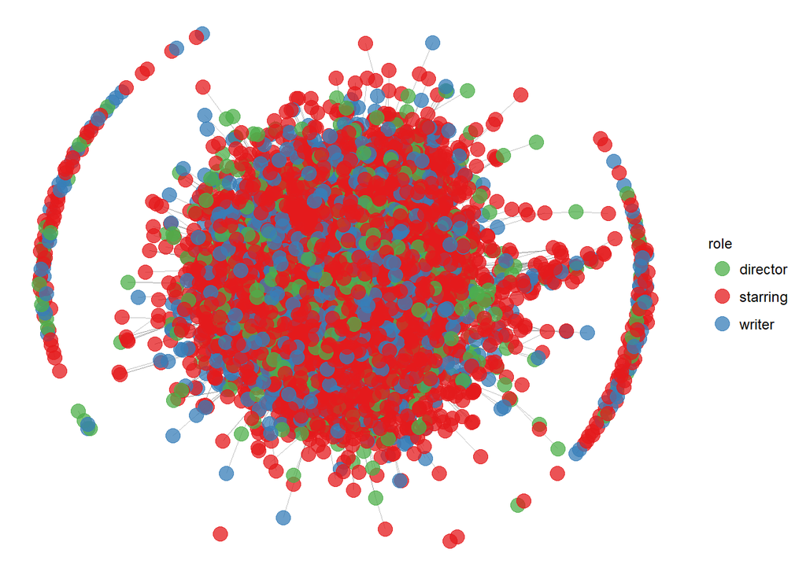

```r
MoviePerson_name <- subset(MoviePerson,select = c(1,2))

relations_new <- merge(x=relations,y=MoviePerson_name,by.x='V1',by.y = 'Person_id')
relations_new <- merge(x=relations_new,y=MoviePerson_name,by.x='V2',by.y = 'Person_id')
rrelations <- subset(relations_new,select = c(5,4))
#relations_actors <- subset(relations_actors, select = c(1,2))
net=network(rrelations,directed = FALSE)

# party affiliation
x = data.frame(Name = network.vertex.names(net))
x = merge(x, MoviePerson, by = "Name", sort = FALSE)$Role
net %v% "role" = as.character(x)

# color palette
y = RColorBrewer::brewer.pal(3, "Set1")[ c(3, 1, 2) ]
names(y) = levels(x)

# network plot
library(GGally)
library(scales)
ggnet2(net, color = "role", palette = y, alpha = 0.75, size = 4, edge.alpha = 0.5)
```

##### Our question:How does actors/actress’ social network relate to their success?

We created two list of actors&actresses

```r
#This is a list of oscar winning actors/actress who are considered to be very successful
#The list is selected from the List of Oscar Academy Award for Best Actor&Actress
oscar_winner_list <- c('Emma Stone','Julia Roberts','Julianne Moore',
                       'Cate Blanchett','Rachel Weisz','Meryl Streep',
                       'Natalie Portman','Nicole Kidman','Kate Winslet',
                       'Charlize Theron','Casey Affleck','Matthew McConaughey',
                       'Colin Firth','Leonardo DiCaprio','Tom Hanks',
                       'Brad Pitt','Christian Bale','Adrien Brody',
                       'Jeff Bridges','Robin Williams')

#This is a list of other stars who are not oscar winners but are also famous and have large fan base.
#The list is selected from IMDB hollywood A-listers popularity data
famous_actor_list <- c('Scarlett Johansson','Marilyn Monroe','Jessica Alba',
                       'Jennifer Aniston','Keira Knightley','Ian McKellen',
                       'Mark Ruffalo','Orlando Bloom','James Franco','Ryan Gosling')
```

We will expolre Actor-Actor relations, Actor-Director relations and Actor-Writer relations. Compare the two star lists in these relations and see what makes them different.

### 1.Analyze Actor-Actor relationship

In this part we will rank the most socialble actors by centrality and compare the sociability of oscar winners, famous stars and the actors population

```r
detach(package:sna)
actors <- subset(MoviePerson,Role=="starring")
id_actors <- c(actors$Person_id)
relations_actors <- subset(relations,V1 %in% id_actors & V2 %in% id_actors & V1!=V2)
actors_full <- graph.data.frame(relations_actors)
actors_full <- as.undirected(actors_full, mode='collapse')
summary(actors_full)
```

```
## IGRAPH e57619d UN-- 7469 25813 --
## + attr: name (v/c)
```

```r
#get actors inner network vertex id
degree_actors <- degree(actors_full)
actors_vertex_id <- as.numeric(rownames(as.data.frame(degree_actors)))

#calculate centrality
#degree centrality
deg_centr_actors <- degree(actors_full)
#closeness centrality
clo_centr_actors <- closeness(actors_full)
#betweenness centrality
bet_centr_actors <- betweenness(actors_full)

#combine into a data frame
actors_name <- subset(actors,select = c(Person_id,Name))
actors_centr <- as.data.frame(cbind(actors_vertex_id,deg_centr_actors,clo_centr_actors,bet_centr_actors))
actors_centr <- merge(x=actors_centr,y=actors_name,by.x="actors_vertex_id",by.y = "Person_id")
actors_centr <- actors_centr[,c('actors_vertex_id','Name','deg_centr_actors','clo_centr_actors','bet_centr_actors')]

#rank by centrality
actors_deg_rank <- actors_centr[order(actors_centr$deg_centr_actors,decreasing = T),]
actors_deg_rank['deg_score'] <- c(nrow(actors_centr):1)
actors_clo_rank <- actors_deg_rank[order(actors_deg_rank$clo_centr_actors,decreasing = T),]
actors_clo_rank['clo_score'] <- c(nrow(actors_centr):1)
actors_bet_rank <- actors_clo_rank[order(actors_clo_rank$bet_centr_actors,decreasing = T),]
actors_bet_rank['bet_score'] <- c(nrow(actors_centr):1)
actors_bet_rank$OverallScore <- actors_bet_rank$deg_score+actors_bet_rank$clo_score+actors_bet_rank$bet_score
actors_rank <- actors_bet_rank[order(actors_bet_rank$OverallScore,decreasing = T),]
actors_rank['rank'] <- c(1:nrow(actors_centr))

#rank of most sociable oscar winners
oscar_actor_rank <- subset(actors_rank,Name %in% oscar_winner_list)
oscar_actor_rank
```

```
##      actors_vertex_id                Name deg_centr_actors
## 5050            11031        Meryl Streep               93
## 3948             8647           Tom Hanks               80
## 1317             2965      Robin Williams               56
## 5508            11989           Brad Pitt               53
## 1097             2506       Nicole Kidman               49
## 872              2007   Leonardo DiCaprio               44
## 3105             6830       Julia Roberts               46
## 3549             7767     Natalie Portman               41
## 4023             8813        Kate Winslet               31
## 5351            11642     Charlize Theron               32
## 7209            15719      Cate Blanchett               31
## 1407             3167      Julianne Moore               34
## 2565             5633      Christian Bale               32
## 3041             6692 Matthew McConaughey               25
```

[output cut: 48 more lines]

```r
summary(oscar_actor_rank)
```

```
##  actors_vertex_id              Name    deg_centr_actors
##  Min.   : 2007    Adrien Brody   : 1   Min.   :10.00
##  1st Qu.: 5401    Brad Pitt      : 1   1st Qu.:23.75
##  Median : 7296    Casey Affleck  : 1   Median :32.00
##  Mean   : 7683    Cate Blanchett : 1   Mean   :37.80
##  3rd Qu.: 9368    Charlize Theron: 1   3rd Qu.:46.75
##  Max.   :15719    Christian Bale : 1   Max.   :93.00
##                   (Other)        :14
##  clo_centr_actors    bet_centr_actors   deg_score      clo_score
##  Min.   :6.626e-07   Min.   :  6354   Min.   :6050   Min.   :5137
##  1st Qu.:6.638e-07   1st Qu.: 63425   1st Qu.:7092   1st Qu.:6878
##  Median :6.646e-07   Median : 86951   Median :7265   Median :7330
##  Mean   :6.644e-07   Mean   :156447   Mean   :7166   Mean   :7066
##  3rd Qu.:6.649e-07   3rd Qu.:183550   3rd Qu.:7378   3rd Qu.:7404
##  Max.   :6.661e-07   Max.   :750236   Max.   :7463   Max.   :7469
##
##    bet_score     OverallScore        rank
##  Min.   :4925   Min.   :16112   Min.   :   2.0
##  1st Qu.:7152   1st Qu.:20995   1st Qu.:  69.0
##  Median :7264   Median :21863   Median : 154.0
##  Mean   :7107   Mean   :21340   Mean   : 314.2
##  3rd Qu.:7398   3rd Qu.:22171   3rd Qu.: 419.8
##  Max.   :7468   Max.   :22400   Max.   :1884.0
##
```

```r
#rank of most sociable famous stars
famous_actor_rank <- subset(actors_rank,Name %in% famous_actor_list)
famous_actor_rank
```

```
##      actors_vertex_id               Name deg_centr_actors clo_centr_actors
## 5700            12386     Marilyn Monroe              102     6.654963e-07
## 1522             3376       Ian McKellen               40     6.646130e-07
## 3672             8051   Jennifer Aniston               33     6.642320e-07
## 673              1556 Scarlett Johansson               31     6.640759e-07
## 73                150       Jessica Alba               25     6.640168e-07
## 6648            14439      Orlando Bloom               25     6.640662e-07
## 2432             5341    Keira Knightley               25     6.637854e-07
## 1696             3791       James Franco               15     6.631423e-07
## 6523            14197       Mark Ruffalo               10     6.637347e-07
## 5230            11403       Ryan Gosling               11     6.633292e-07
##      bet_centr_actors deg_score clo_score bet_score OverallScore rank
## 5700       510702.385      7465      7457      7463        22385    8
## 1522       157312.611      7344      7334      7379        22057  103
## 3672        79499.264      7278      7189      7235        21702  211
## 673         86707.233      7255      7111      7262        21628  234
## 73          59252.689      7141      7070      7124        21335  323
## 6648        44288.492      7120      7102      6996        21218  351
## 2432        44556.617      7135      6869      6999        21003  424
## 1696        32175.130      6672      6113      6813        19598  808
## 6523        10257.764      6000      6826      5722        18548 1132
## 5230         9690.422      6194      6383      5667        18244 1214
```

```r
summary(famous_actor_rank)
```

```
##  actors_vertex_id               Name   deg_centr_actors
##  Min.   :  150    Ian McKellen    :1   Min.   : 10.0
##  1st Qu.: 3480    James Franco    :1   1st Qu.: 17.5
##  Median : 6696    Jennifer Aniston:1   Median : 25.0
##  Mean   : 7469    Jessica Alba    :1   Mean   : 31.7
##  3rd Qu.:12140    Keira Knightley :1   3rd Qu.: 32.5
##  Max.   :14439    Marilyn Monroe  :1   Max.   :102.0
##                   (Other)         :4
##  clo_centr_actors    bet_centr_actors   deg_score      clo_score
##  Min.   :6.631e-07   Min.   :  9690   Min.   :6000   Min.   :6113
##  1st Qu.:6.637e-07   1st Qu.: 35204   1st Qu.:6784   1st Qu.:6837
##  Median :6.640e-07   Median : 51905   Median :7138   Median :7086
##  Mean   :6.640e-07   Mean   :103444   Mean   :6960   Mean   :6945
##  3rd Qu.:6.642e-07   3rd Qu.: 84905   3rd Qu.:7272   3rd Qu.:7170
##  Max.   :6.655e-07   Max.   :510702   Max.   :7465   Max.   :7457
##
##    bet_score     OverallScore        rank
##  Min.   :5667   Min.   :18244   Min.   :   8.0
##  1st Qu.:6859   1st Qu.:19949   1st Qu.: 216.8
##  Median :7062   Median :21277   Median : 337.0
##  Mean   :6866   Mean   :20772   Mean   : 480.8
##  3rd Qu.:7255   3rd Qu.:21684   3rd Qu.: 712.0
##  Max.   :7463   Max.   :22385   Max.   :1214.0
##
```

```r
#rank of all the actors/actress
actors_rank[1:20,]
```

```
##      actors_vertex_id                  Name deg_centr_actors
## 2072             4621            John Wayne              204
## 5050            11031          Meryl Streep               93
## 5181            11316         Elvis Presley              115
## 3150             6938         Frank Sinatra              140
## 6096            13275           Bette Davis              120
## 3164             6963     Katharine Hepburn               95
## 5058            11046        Jack Nicholson               87
## 5700            12386        Marilyn Monroe              102
## 4598            10058           Dean Martin               92
## 3948             8647             Tom Hanks               80
## 5281            11502           Henry Fonda               92
## 4872            10653        Robert De Niro               72
## 2666             5837      Elizabeth Taylor               82
## 895              2055 Madonna (entertainer)               72
```

[output cut: 48 more lines]

```r
summary(actors_rank)
```

```
##  actors_vertex_id                   Name      deg_centr_actors
##  Min.   :    0    A Martinez          :   1   Min.   :  1.000
##  1st Qu.: 4163    A. J. Cook (actress):   1   1st Qu.:  2.000
##  Median : 8198    Ã©dgar RamÃrez     :   1   Median :  4.000
##  Mean   : 8175    Aaliyah             :   1   Mean   :  6.912
##  3rd Qu.:12168    Aaron Ashmore       :   1   3rd Qu.:  8.000
##  Max.   :16254    Aaron Eckhart       :   1   Max.   :204.000
##                   (Other)             :7463
##  clo_centr_actors    bet_centr_actors    deg_score      clo_score
##  Min.   :1.793e-08   Min.   :      0   Min.   :   1   Min.   :   1
##  1st Qu.:6.603e-07   1st Qu.:      0   1st Qu.:1868   1st Qu.:1868
##  Median :6.618e-07   Median :   1551   Median :3735   Median :3735
##  Mean   :6.444e-07   Mean   :  12518   Mean   :3735   Mean   :3735
##  3rd Qu.:6.628e-07   3rd Qu.:   9240   3rd Qu.:5602   3rd Qu.:5602
##  Max.   :6.661e-07   Max.   :1106394   Max.   :7469   Max.   :7469
##
##    bet_score     OverallScore        rank
##  Min.   :   1   Min.   :   12   Min.   :   1
##  1st Qu.:1868   1st Qu.: 6275   1st Qu.:1868
##  Median :3735   Median :11062   Median :3735
##  Mean   :3735   Mean   :11205   Mean   :3735
##  3rd Qu.:5602   3rd Qu.:16144   3rd Qu.:5602
##  Max.   :7469   Max.   :22406   Max.   :7469
##
```

From the summary, we can see oscar winners have higher average degree centrality, higher average betweenness centrality, and higher closeness centrality compared to famous stars, and famous stars all have higher centrality compared to average centrality of all the stars

### 2.Analyze Actor-Director relationship

In this part, we will explore the relationship between actors and directors, and rank the actors by the number of directors they know. We will also compare the oscar winners, famous stars and the actors population

```r
ActDir <- subset(MoviePerson,Role=="starring"|Role=="director")
directors <- subset(MoviePerson,Role=="director")
id_directors <- c(directors$Person_id)
#only relations between actors and directors, we omit relations between actors and actors
# and relations between directors and directors
relations_ActDir_only <- subset(relations,(V1 %in% id_actors & V2 %in% id_directors) | (V1 %in% id_directors & V2 %in% id_actors))
ActDir_only <- graph.data.frame(relations_ActDir_only)
ActDir_only <- as.undirected(ActDir_only, mode='collapse')
summary(ActDir_only)
```

```
## IGRAPH eb94395 UN-- 6329 13470 --
## + attr: name (v/c)
```

```r
#degree centrality and vertex id
degree_ActDir_only <- degree(ActDir_only)
ActDir_only_vertex_id <- as.numeric(rownames(as.data.frame(degree_ActDir_only)))

#combine into a data frame
ActDir_name <- subset(ActDir,select = c(Person_id,Name,Role))
ActDir_degree <- as.data.frame(cbind(ActDir_only_vertex_id,degree_ActDir_only))
ActDir_degree <- merge(x=ActDir_degree,y=ActDir_name,by.x="ActDir_only_vertex_id",by.y = "Person_id")
ActDir_degree <- ActDir_degree[,c('ActDir_only_vertex_id','Name','Role','degree_ActDir_only')]
ActDir_degree.actors <- subset(ActDir_degree,Role=='starring')
#A rank of actors that know most directors
ActDir.actors_deg_rank <- ActDir_degree.actors[order(ActDir_degree.actors$degree_ActDir_only ,decreasing = T),]
ActDir.actors_deg_rank['rank'] <- c(1:nrow(ActDir.actors_deg_rank))

#rank of oscar winners who know most directors
oscar_actor_dir_rank <- subset(ActDir.actors_deg_rank,Name %in% oscar_winner_list)
summary(oscar_actor_dir_rank)
```

```
##  ActDir_only_vertex_id              Name          Role
##  Min.   : 2007         Adrien Brody   : 1   director: 0
##  1st Qu.: 5401         Brad Pitt      : 1   starring:20
##  Median : 7296         Casey Affleck  : 1   writer  : 0
##  Mean   : 7683         Cate Blanchett : 1
##  3rd Qu.: 9368         Charlize Theron: 1
##  Max.   :15719         Christian Bale : 1
##                        (Other)        :14
##  degree_ActDir_only      rank
##  Min.   : 2.00      Min.   :  11.00
##  1st Qu.: 7.00      1st Qu.:  88.75
##  Median :11.00      Median : 162.00
##  Mean   :11.30      Mean   : 336.15
##  3rd Qu.:13.25      3rd Qu.: 367.00
##  Max.   :26.00      Max.   :2152.00
##
```

```r
oscar_actor_dir_rank
```

```
##      ActDir_only_vertex_id                Name     Role degree_ActDir_only
## 3327                  8647           Tom Hanks starring                 26
## 4648                 11989           Brad Pitt starring                 22
## 1109                  2965      Robin Williams starring                 20
## 4253                 11031        Meryl Streep starring                 19
## 946                   2506       Nicole Kidman starring                 14
## 2612                  6830       Julia Roberts starring                 13
## 770                   2007   Leonardo DiCaprio starring                 11
## 1183                  3167      Julianne Moore starring                 11
## 2977                  7767     Natalie Portman starring                 11
## 3394                  8813        Kate Winslet starring                 11
## 6111                 15719      Cate Blanchett starring                 11
## 1792                  4704        Adrien Brody starring                  9
## 5686                 14682       Casey Affleck starring                  9
## 2813                  7353        Jeff Bridges starring                  8
```

[output cut: 27 more lines]

```r
#rank of famous stars who know most directors
famous_actor_dir_rank <- subset(ActDir.actors_deg_rank,Name %in% famous_actor_list)
summary(famous_actor_dir_rank)
```

```
##  ActDir_only_vertex_id               Name         Role
##  Min.   :  150         Ian McKellen    :1   director: 0
##  1st Qu.: 3480         James Franco    :1   starring:10
##  Median : 6696         Jennifer Aniston:1   writer  : 0
##  Mean   : 7469         Jessica Alba    :1
##  3rd Qu.:12140         Keira Knightley :1
##  Max.   :14439         Marilyn Monroe  :1
##                        (Other)         :4
##  degree_ActDir_only      rank
##  Min.   : 3.00      Min.   :   5.0
##  1st Qu.: 5.25      1st Qu.: 272.8
##  Median : 6.00      Median : 459.5
##  Mean   : 8.50      Mean   : 587.2
##  3rd Qu.: 8.25      3rd Qu.: 574.0
##  Max.   :31.00      Max.   :1544.0
##
```

```r
famous_actor_dir_rank
```

```
##      ActDir_only_vertex_id               Name     Role degree_ActDir_only
## 4810                 12386     Marilyn Monroe starring                 31
## 5511                 14197       Mark Ruffalo starring                 10
## 44                     150       Jessica Alba starring                  9
## 587                   1556 Scarlett Johansson starring                  6
## 1267                  3376       Ian McKellen starring                  6
## 1420                  3791       James Franco starring                  6
## 3089                  8051   Jennifer Aniston starring                  6
## 2033                  5341    Keira Knightley starring                  5
## 4415                 11403       Ryan Gosling starring                  3
## 5607                 14439      Orlando Bloom starring                  3
##      rank
## 4810    5
## 5511  209
## 44    216
## 587   443
## 1267  457
## 1420  462
## 3089  484
## 2033  604
## 4415 1448
## 5607 1544
```

```r
#rank of all the actors who know most directors
summary(ActDir.actors_deg_rank)
```

```
##  ActDir_only_vertex_id              Name            Role
##  Min.   :    0         Ã©dgar RamÃrez:   1   director:   0
##  1st Qu.: 4271         Aaliyah        :   1   starring:4727
##  Median : 8279         Aaron Ashmore  :   1   writer  :   0
##  Mean   : 8261         Aaron Eckhart  :   1
##  3rd Qu.:12226         Aaron Yoo      :   1
##  Max.   :16249         Aasif Mandvi   :   1
##                        (Other)        :4721
##  degree_ActDir_only      rank
##  Min.   : 1.00      Min.   :   1
##  1st Qu.: 1.00      1st Qu.:1182
##  Median : 2.00      Median :2364
##  Mean   : 2.85      Mean   :2364
##  3rd Qu.: 3.00      3rd Qu.:3546
##  Max.   :42.00      Max.   :4727
##
```

```r
ActDir.actors_deg_rank[1:20,]
```

```
##      ActDir_only_vertex_id                  Name     Role
## 2071                  5424          Martin Sheen starring
## 1758                  4621            John Wayne starring
## 4378                 11316         Elvis Presley starring
## 77                     231          Gene Tierney starring
## 4810                 12386        Marilyn Monroe starring
## 785                   2055 Madonna (entertainer) starring
## 5152                 13275           Bette Davis starring
## 1001                  2664        Robert Mitchum starring
## 2962                  7714         Marlon Brando starring
## 3238                  8430            Val Kilmer starring
## 3327                  8647             Tom Hanks starring
## 4106                 10653        Robert De Niro starring
## 4262                 11046        Jack Nicholson starring
## 1900                  5012         Michael Caine starring
```

[output cut: 27 more lines]

From the summary, we can see oscar winners know average more directors than famous stars,and famous stars know more directors than the population

### 3.Analyze Actor-Writer relationship

In this part, we will explore the relationship between actors and writers,and rank the actors by the number of writers they know. We will also compare the two star lists.

```r
ActWri <- subset(MoviePerson,Role=="starring"|Role=="writer")
writers <- subset(MoviePerson,Role=="writer")
id_writers <- c(writers$Person_id)

#only relations between actors and writers
relations_ActWri_only <- subset(relations,(V1 %in% id_actors & V2 %in% id_writers) | (V1 %in% id_writers & V2 %in% id_actors))
ActWri_only <- graph.data.frame(relations_ActWri_only)
ActWri_only <- as.undirected(ActWri_only, mode='collapse')
summary(ActWri_only)
```

```
## IGRAPH ebbab20 UN-- 7416 15666 --
## + attr: name (v/c)
```

```r
#degree centrality and vertex id
degree_ActWri_only <- degree(ActWri_only)
ActWri_only_vertex_id <- as.numeric(rownames(as.data.frame(degree_ActWri_only)))

#combine into a data frame
ActWri_name <- subset(ActWri,select = c(Person_id,Name,Role))
ActWri_degree <- as.data.frame(cbind(ActWri_only_vertex_id,degree_ActWri_only))
ActWri_degree <- merge(x=ActWri_degree,y=ActWri_name,by.x="ActWri_only_vertex_id",by.y = "Person_id")
ActWri_degree <- ActWri_degree[,c('ActWri_only_vertex_id','Name','Role','degree_ActWri_only')]
ActWri_degree.actors <- subset(ActWri_degree,Role=='starring')
#A rank of actors that know most writers
ActWri.actors_deg_rank <- ActWri_degree.actors[order(ActWri_degree.actors$degree_ActWri_only ,decreasing = T),]
ActWri.actors_deg_rank['rank'] <- c(1:nrow(ActWri.actors_deg_rank))

#rank of oscar winners who know most writers
oscar_actor_wri_rank <- subset(ActWri.actors_deg_rank,Name %in% oscar_winner_list)
summary(oscar_actor_wri_rank)
```

```
##  ActWri_only_vertex_id              Name          Role
##  Min.   : 2007         Adrien Brody   : 1   director: 0
##  1st Qu.: 5401         Brad Pitt      : 1   starring:20
##  Median : 7296         Casey Affleck  : 1   writer  : 0
##  Mean   : 7683         Cate Blanchett : 1
##  3rd Qu.: 9368         Charlize Theron: 1
##  Max.   :15719         Christian Bale : 1
##                        (Other)        :14
##  degree_ActWri_only      rank
##  Min.   : 3.00      Min.   :   4.0
##  1st Qu.: 7.75      1st Qu.:  79.0
##  Median :12.00      Median : 161.0
##  Mean   :14.55      Mean   : 289.6
##  3rd Qu.:15.00      3rd Qu.: 377.0
##  Max.   :37.00      Max.   :1597.0
##
```

```r
oscar_actor_wri_rank
```

```
##      ActWri_only_vertex_id                Name     Role degree_ActWri_only
## 4994                 11031        Meryl Streep starring                 37
## 3884                  8647           Tom Hanks starring                 33
## 1326                  2965      Robin Williams starring                 31
## 5428                 11989           Brad Pitt starring                 27
## 1117                  2506       Nicole Kidman starring                 15
## 2548                  5633      Christian Bale starring                 15
## 7171                 15719      Cate Blanchett starring                 15
## 3493                  7767     Natalie Portman starring                 14
## 883                   2007   Leonardo DiCaprio starring                 13
## 3078                  6830       Julia Roberts starring                 13
## 3262                  7238         Colin Firth starring                 11
## 3308                  7353        Jeff Bridges starring                 11
## 1419                  3167      Julianne Moore starring                 10
## 5277                 11642     Charlize Theron starring                 10
```

[output cut: 27 more lines]

```r
#rank of famous actors/actress who know most writers
famous_actor_wri_rank <- subset(ActWri.actors_deg_rank,Name %in% famous_actor_list)
summary(famous_actor_wri_rank)
```

```
##  ActWri_only_vertex_id               Name         Role
##  Min.   :  150         Ian McKellen    :1   director: 0
##  1st Qu.: 3480         James Franco    :1   starring:10
##  Median : 6696         Jennifer Aniston:1   writer  : 0
##  Mean   : 7469         Jessica Alba    :1
##  3rd Qu.:12140         Keira Knightley :1
##  Max.   :14439         Marilyn Monroe  :1
##                        (Other)         :4
##  degree_ActWri_only      rank
##  Min.   : 2.0       Min.   :  11.0
##  1st Qu.: 4.0       1st Qu.: 347.5
##  Median : 6.0       Median : 671.0
##  Mean   : 8.3       Mean   : 747.0
##  3rd Qu.: 8.0       3rd Qu.:1052.2
##  Max.   :30.0       Max.   :1874.0
##
```

```r
famous_actor_wri_rank
```

```
##      ActWri_only_vertex_id               Name     Role degree_ActWri_only
## 5613                 12386     Marilyn Monroe starring                 30
## 692                   1556 Scarlett Johansson starring                 11
## 1516                  3376       Ian McKellen starring                  8
## 3619                  8051   Jennifer Aniston starring                  8
## 5170                 11403       Ryan Gosling starring                  6
## 6439                 14197       Mark Ruffalo starring                  6
## 1687                  3791       James Franco starring                  4
## 2406                  5341    Keira Knightley starring                  4
## 6557                 14439      Orlando Bloom starring                  4
## 68                     150       Jessica Alba starring                  2
##      rank
## 5613   11
## 692   177
## 1516  339
## 3619  373
## 5170  654
## 6439  688
## 1687 1029
## 2406 1060
## 6557 1265
## 68   1874
```

```r
#rank of all actors/actress who know most writers
summary(ActWri.actors_deg_rank)
```

```
##  ActWri_only_vertex_id              Name            Role
##  Min.   :    0         A. J. Langer   :   1   director:   0
##  1st Qu.: 4206         Ã©dgar RamÃrez:   1   starring:5124
##  Median : 8255         Aaliyah        :   1   writer  :   0
##  Mean   : 8200         Aaron Eckhart  :   1
##  3rd Qu.:12216         Aaron Norris   :   1
##  Max.   :16249         Aasif Mandvi   :   1
##                        (Other)        :5118
##  degree_ActWri_only      rank
##  Min.   : 1.000     Min.   :   1
##  1st Qu.: 1.000     1st Qu.:1282
##  Median : 2.000     Median :2562
##  Mean   : 3.057     Mean   :2562
##  3rd Qu.: 4.000     3rd Qu.:3843
##  Max.   :59.000     Max.   :5124
##
```

```r
ActWri.actors_deg_rank[1:20,]
```

```
##      ActWri_only_vertex_id                  Name     Role
## 5128                 11316         Elvis Presley starring
## 3124                  6938         Frank Sinatra starring
## 3517                  7827           The Beatles starring
## 4994                 11031          Meryl Streep starring
## 6979                 15340          Winona Ryder starring
## 904                   2055 Madonna (entertainer) starring
## 2051                  4621            John Wayne starring
## 3884                  8647             Tom Hanks starring
## 1326                  2965        Robin Williams starring
## 4583                 10152    The Rolling Stones starring
## 5613                 12386        Marilyn Monroe starring
## 6006                 13275           Bette Davis starring
## 2242                  5012         Michael Caine starring
## 3134                  6963     Katharine Hepburn starring
```

[output cut: 27 more lines]

From the summary, we can see oscar winners know average more writers than famous stars,and famous stars know more writers than the population ######from the analysis above, we can see oscar winning actors/actress have generally more connections  
######with their peer actors/actress, directors and writers compared to other famous actors/actress

###### In the next two part we will select a list of most authoritative directors and writers according

###### to their sociability and see their impact on the stars

### 4.Analyze directors network

In this part we will rank the most authoritative directors by centrality in the full network

```r
relations_directors <- subset(relations,V1 %in% id_directors | V2 %in% id_directors & V1!=V2)
directors_full <- graph.data.frame(relations_directors)
directors_full <- as.undirected(directors_full, mode='collapse')
summary(directors_full)
```

```
## IGRAPH ebdfe1d UN-- 8467 21361 --
## + attr: name (v/c)
```

```r
#get directors network vertex id
degree_directors <- degree(directors_full)
directors_vertex_id <- as.numeric(rownames(as.data.frame(degree_directors)))

#calculate centrality
#degree centrality
deg_centr_directors <- degree(directors_full)
#closeness centrality
clo_centr_directors <- closeness(directors_full)
#betweenness centrality
bet_centr_directors <- betweenness(directors_full)

#combine into a data frame
name <- subset(MoviePerson,select = c(Person_id,Name,Role))
directors_centr <- as.data.frame(cbind(directors_vertex_id,deg_centr_directors,clo_centr_directors,bet_centr_directors))
directors_centr <- merge(x=directors_centr,y=name,by.x="directors_vertex_id",by.y = "Person_id")
directors_centr <- directors_centr[,c('directors_vertex_id','Name','Role','deg_centr_directors','clo_centr_directors','bet_centr_directors')]
directors_centr <- subset(directors_centr,Role=='director')
#rank by centrality
directors_deg_rank <- directors_centr[order(directors_centr$deg_centr_directors,decreasing = T),]
directors_deg_rank['deg_score'] <- c(nrow(directors_centr):1)
directors_clo_rank <- directors_deg_rank[order(directors_deg_rank$clo_centr_directors,decreasing = T),]
directors_clo_rank['clo_score'] <- c(nrow(directors_centr):1)
directors_bet_rank <- directors_clo_rank[order(directors_clo_rank$bet_centr_directors,decreasing = T),]
directors_bet_rank['bet_score'] <- c(nrow(directors_centr):1)
directors_bet_rank$OverallScore <- directors_bet_rank$deg_score+directors_bet_rank$clo_score+directors_bet_rank$bet_score
directors_rank <- directors_bet_rank[order(directors_bet_rank$OverallScore,decreasing = T),]
directors_rank['rank'] <- c(1:nrow(directors_centr))
sociable_directors <- directors_rank[0:100,]
sociable_directors_list <- as.character(sociable_directors$Name)
sociable_directors_id <- as.numeric(sociable_directors$directors_vertex_id)
sociable_directors[1:20,]
```

```
##      directors_vertex_id              Name     Role deg_centr_directors
## 1978                3869  Steven Spielberg director                 274
## 2090                4058  Alfred Hitchcock director                 271
## 6904               13320   Martin Scorsese director                 179
## 3970                7701    Clint Eastwood director                 176
## 7355               14178  Laurence Olivier director                 201
## 6223               12021     Robert Altman director                 141
## 332                  627      Sidney Lumet director                 153
## 4695                9090      Sean Connery director                 124
## 718                 1395     Sam Peckinpah director                 116
## 5786               11190       Paul Newman director                 120
## 5086                9881         Al Pacino director                 127
## 6025               11619       Johnny Depp director                 123
## 1968                3855  Charles Laughton director                 134
## 6856               13242        Tom Cruise director                 128
```

[output cut: 48 more lines]

### 5.Analyze writers network

In this part we will rank the most authoritative writers by centrality in the full network

```r
relations_writers <- subset(relations,V1 %in% id_writers | V2 %in% id_writers & V1!=V2)
writers_full <- graph.data.frame(relations_writers)
writers_full <- as.undirected(writers_full, mode='collapse')
summary(writers_full)
```

```
## IGRAPH f26e675 UN-- 9511 26718 --
## + attr: name (v/c)
```

```r
#get writers network vertex id
degree_writers <- degree(writers_full)
writers_vertex_id <- as.numeric(rownames(as.data.frame(degree_writers)))

#calculate centrality
#degree centrality
deg_centr_writers <- degree(writers_full)
#closeness centrality
clo_centr_writers <- closeness(writers_full)
#betweenness centrality
bet_centr_writers <- betweenness(writers_full)

#combine into a data frame
name <- subset(MoviePerson,select = c(Person_id,Name,Role))
writers_centr <- as.data.frame(cbind(writers_vertex_id,deg_centr_writers,clo_centr_writers,bet_centr_writers))
writers_centr <- merge(x=writers_centr,y=name,by.x="writers_vertex_id",by.y = "Person_id")
writers_centr <- writers_centr[,c('writers_vertex_id','Name','Role','deg_centr_writers','clo_centr_writers','bet_centr_writers')]
writers_centr <- subset(writers_centr,Role=='writer')
#rank by centrality
writers_deg_rank <- writers_centr[order(writers_centr$deg_centr_writers,decreasing = T),]
writers_deg_rank['deg_score'] <- c(nrow(writers_centr):1)
writers_clo_rank <- writers_deg_rank[order(writers_deg_rank$clo_centr_writers,decreasing = T),]
writers_clo_rank['clo_score'] <- c(nrow(writers_centr):1)
writers_bet_rank <- writers_clo_rank[order(writers_clo_rank$bet_centr_writers,decreasing = T),]
writers_bet_rank['bet_score'] <- c(nrow(writers_centr):1)
writers_bet_rank$OverallScore <- writers_bet_rank$deg_score+writers_bet_rank$clo_score+writers_bet_rank$bet_score
writers_rank <- writers_bet_rank[order(writers_bet_rank$OverallScore,decreasing = T),]
writers_rank['rank'] <- c(1:nrow(writers_centr))
sociable_writers <- writers_rank[0:100,]
sociable_writers_list <- as.character(sociable_writers$Name)
sociable_writers_id <- as.numeric(sociable_writers$writers_vertex_id)
sociable_writers[1:20,]
```

```
##      writers_vertex_id                  Name   Role deg_centr_writers
## 5235              8974          Orson Welles writer               247
## 8964             15326           Woody Allen writer               190
## 9232             15760  Francis Ford Coppola writer               150
## 812               1379        Terry Southern writer               126
## 6087             10425          Stephen King writer               147
## 8191             14029            Tim Burton writer               145
## 4663              8010           Roger Ebert writer               117
## 6490             11121      Barbra Streisand writer               127
## 2913              4994     Quentin Tarantino writer               135
## 1043              1782          Billy Wilder writer               113
## 1872              3175       Stanley Kubrick writer               123
## 1428              2427            Neil Simon writer               130
## 5710              9797          Steve Martin writer               115
## 6039             10341 Arnold Schwarzenegger writer               115
```

[output cut: 48 more lines]

### 6.Number of important directors and writers oscar winners and famous stars know

```r
oscar_actor_id <- as.numeric(oscar_actor_rank$actors_vertex_id)
oscar_actor_name <- subset(oscar_actor_rank,select=c(actors_vertex_id,Name))
##number of sociable directors oscar winners know
oscar_actor_Auth_Dir <- subset(relations,(V1 %in% oscar_actor_id & V2 %in% sociable_directors_id) |
         (V2 %in% oscar_actor_id & V1 %in% sociable_directors_id))
oscar_actor_Auth_Dir_full <- graph.data.frame(oscar_actor_Auth_Dir)
oscar_actor_Auth_Dir_full <- as.undirected(oscar_actor_Auth_Dir_full, mode='collapse')
summary(oscar_actor_Auth_Dir_full)
```

```
## IGRAPH fb95102 UN-- 62 98 --
## + attr: name (v/c)
```

```r
degree_oscar_actor_Auth_Dir <- degree(oscar_actor_Auth_Dir_full)

oscar_actor_Auth_Dir_vertex_id <- as.numeric(rownames(as.data.frame(degree_oscar_actor_Auth_Dir)))
oscar_actor_Auth_Dir_degree <- as.data.frame(cbind(oscar_actor_Auth_Dir_vertex_id,degree_oscar_actor_Auth_Dir))
oscar_actor_Auth_Dir_degree <- subset(oscar_actor_Auth_Dir_degree,oscar_actor_Auth_Dir_vertex_id %in% oscar_actor_id)
oscar_actor_Auth_Dir_degree <- merge(x=oscar_actor_Auth_Dir_degree,y=oscar_actor_name,
                                     by.x='oscar_actor_Auth_Dir_vertex_id',by.y = 'actors_vertex_id')
oscar_actor_Auth_Dir_degree <- oscar_actor_Auth_Dir_degree[order(oscar_actor_Auth_Dir_degree$degree_oscar_actor_Auth_Dir,decreasing = T),]
##mean authoritative directors oscar winners know
sum(oscar_actor_Auth_Dir_degree$degree_oscar_actor_Auth_Dir)/20
```

```
## [1] 4.9
```

```r
##number of sociable writers oscar winners know
oscar_actor_Auth_Wri <- subset(relations,(V1 %in% oscar_actor_id & V2 %in% sociable_writers_id)                                |(V2 %in% oscar_actor_id & V1 %in% sociable_writers_id))
oscar_actor_Auth_Wri_full <- graph.data.frame(oscar_actor_Auth_Wri)
oscar_actor_Auth_Wri_full <- as.undirected(oscar_actor_Auth_Wri_full, mode='collapse')
summary(oscar_actor_Auth_Wri_full)
```

```
## IGRAPH fb98bd3 UN-- 65 82 --
## + attr: name (v/c)
```

```r
degree_oscar_actor_Auth_Wri <- degree(oscar_actor_Auth_Wri_full)

oscar_actor_Auth_Wri_vertex_id <- as.numeric(rownames(as.data.frame(degree_oscar_actor_Auth_Wri)))
oscar_actor_Auth_Wri_degree <- as.data.frame(cbind(oscar_actor_Auth_Wri_vertex_id,degree_oscar_actor_Auth_Wri))
oscar_actor_Auth_Wri_degree <- subset(oscar_actor_Auth_Wri_degree,oscar_actor_Auth_Wri_vertex_id %in% oscar_actor_id)
oscar_actor_Auth_Wri_degree <- merge(x=oscar_actor_Auth_Wri_degree,y=oscar_actor_name,
                                     by.x='oscar_actor_Auth_Wri_vertex_id',by.y = 'actors_vertex_id')
oscar_actor_Auth_Wri_degree <- oscar_actor_Auth_Wri_degree[order(oscar_actor_Auth_Wri_degree$degree_oscar_actor_Auth_Wri,decreasing = T),]
##mean authoritative writers oscar winners know
sum(oscar_actor_Auth_Wri_degree$degree_oscar_actor_Auth_Wri)/20
```

```
## [1] 4.1
```

```r
famous_actor_id <- as.numeric(famous_actor_rank$actors_vertex_id)
famous_actor_name <- subset(famous_actor_rank,select=c(actors_vertex_id,Name))
##number of sociable directors famous actors know
famous_actor_Auth_Dir <- subset(relations,(V1 %in% famous_actor_id & V2 %in% sociable_directors_id) |
         (V2 %in% famous_actor_id & V1 %in% sociable_directors_id))
famous_actor_Auth_Dir_full <- graph.data.frame(famous_actor_Auth_Dir)
famous_actor_Auth_Dir_full <- as.undirected(famous_actor_Auth_Dir_full, mode='collapse')
summary(famous_actor_Auth_Dir_full)
```

```
## IGRAPH fba2fd6 UN-- 35 33 --
## + attr: name (v/c)
```

```r
degree_famous_actor_Auth_Dir <- degree(famous_actor_Auth_Dir_full)

famous_actor_Auth_Dir_vertex_id <- as.numeric(rownames(as.data.frame(degree_famous_actor_Auth_Dir)))
famous_actor_Auth_Dir_degree <- as.data.frame(cbind(famous_actor_Auth_Dir_vertex_id,degree_famous_actor_Auth_Dir))
famous_actor_Auth_Dir_degree <- subset(famous_actor_Auth_Dir_degree,famous_actor_Auth_Dir_vertex_id %in% famous_actor_id)
famous_actor_Auth_Dir_degree <- merge(x=famous_actor_Auth_Dir_degree,y=famous_actor_name,
                                     by.x='famous_actor_Auth_Dir_vertex_id',by.y = 'actors_vertex_id')
famous_actor_Auth_Dir_degree <- famous_actor_Auth_Dir_degree[order(famous_actor_Auth_Dir_degree$degree_famous_actor_Auth_Dir,decreasing = T),]
##mean authoritative directors famous actors know
sum(famous_actor_Auth_Dir_degree$degree_famous_actor_Auth_Dir)/10
```

```
## [1] 3.3
```

```r
##number of sociable writers oscar winners know
famous_actor_Auth_Wri <- subset(relations,(V1 %in% famous_actor_id & V2 %in% sociable_writers_id) |
                                 (V2 %in% famous_actor_id & V1 %in% sociable_writers_id))
famous_actor_Auth_Wri_full <- graph.data.frame(famous_actor_Auth_Wri)
famous_actor_Auth_Wri_full <- as.undirected(famous_actor_Auth_Wri_full, mode='collapse')
summary(famous_actor_Auth_Wri_full)
```

```
## IGRAPH fba6822 UN-- 23 21 --
## + attr: name (v/c)
```

```r
degree_famous_actor_Auth_Wri <- degree(famous_actor_Auth_Wri_full)

famous_actor_Auth_Wri_vertex_id <- as.numeric(rownames(as.data.frame(degree_famous_actor_Auth_Wri)))
famous_actor_Auth_Wri_degree <- as.data.frame(cbind(famous_actor_Auth_Wri_vertex_id,degree_famous_actor_Auth_Wri))
famous_actor_Auth_Wri_degree <- subset(famous_actor_Auth_Wri_degree,famous_actor_Auth_Wri_vertex_id %in% famous_actor_id)
famous_actor_Auth_Wri_degree <- merge(x=famous_actor_Auth_Wri_degree,y=famous_actor_name,
                                     by.x='famous_actor_Auth_Wri_vertex_id',by.y = 'actors_vertex_id')
famous_actor_Auth_Wri_degree <- famous_actor_Auth_Wri_degree[order(famous_actor_Auth_Wri_degree$degree_famous_actor_Auth_Wri,decreasing = T),]
##mean authoritative writers famous actors know
sum(famous_actor_Auth_Wri_degree$degree_famous_actor_Auth_Wri)/10
```

```
## [1] 2.1
```

```r
##mean authoritative directors all the actors know
all_dir <- subset(relations,(V1 %in% sociable_directors_id)|(V2 %in% sociable_directors_id))
all_dir_full <- graph.data.frame(all_dir)
all_dir_full <- as.undirected(all_dir_full, mode='collapse')
all_dir.degree <- degree(all_dir_full)
degree.all_dir <- as.numeric(all_dir.degree)
sum(degree.all_dir)/nrow(actors)
```

```
## [1] 1.606677
```

```r
##mean authoritative writers all the actors know
all_wri <- subset(relations,(V1 %in% sociable_writers_id)|(V2 %in% sociable_writers_id))
all_wri_full <- graph.data.frame(all_wri)
all_wri_full <- as.undirected(all_wri_full, mode='collapse')
all_wri.degree <- degree(all_wri_full)
degree.all_wri <- as.numeric(all_wri.degree)
sum(degree.all_wri)/nrow(actors)
```

```
## [1] 1.581588
```

We can see oscar winners know averge more authoritative directors/writers than famous stars, famous stars know averge more authoritative directors/writers than the all the actors